# Simulating behaviors for model confusion analysis

# Goal

In a previous set of analyses, we established that our parameter estimation procedure allows us to recover known/simulated parameter values with acceptable accuracy. We then fit parameters for each model, for each real human subject.

Later on, we want to make inferences about what model(s) best fit human subjects’ behaviors. However, since we don’t know what “true” model humans are using, it would be nice to know how likely it is that we’d (mistakenly) infer that model X is the best-fitting model, given that model Y is actually the data-generating mechanism.

To do this, we’ll perform a “model confusion” analysis. The idea is that we’ll use our empirical distributions of parameter fits to simulate behavior, then to fit every model on every simulated dataset. If the models are highly confusable, this hinders our ability to make strong inferences during the model selection process.

# Setup

```r
workflow_name <- "netnav_05_model_confusion"

library(tidyverse)
library(here)
```

```r
library(patchwork)

source(here("code", "utils", "modeling_utils.R"))
source(here("code", "utils", "representation_utils.R"))

source(here("code", "utils", "ggplot_themes.R"))
source(here("code", "utils", "kable_utils.R"))
source(here("code", "utils", "unicode_greek.R"))

knitting <- knitr::is_html_output()

create_path <- function(this_path) {
  if (!dir.exists(this_path)) {
    dir.create(this_path, recursive = TRUE)
  }
}

if (knitting) {
  here("outputs", workflow_name) %>%
    create_path()
}
```

```r
bfs_backward_sims <- here(
  "data", "bfs_sims", "bfs_sims_learned_backward.csv"
) %>%
  read_csv(show_col_types = FALSE) %>%
  filter(
    shortest_path_given_opts == shortest_path_given_start_end,
    two_correct_options == FALSE
  ) %>%
  mutate(shortest_path = factor(shortest_path_given_opts)) %>%
  select(-starts_with("shortest_path_given"), -two_correct_options) %>%
  group_by(
    shortest_path, startpoint_id, endpoint_id, opt1_id, opt2_id, correct_choice
  ) %>%
  summarise(
    p_bfs_correct = mean(bfs_choice == correct_choice),
    p_bfs_chooses_opt1 = mean(bfs_choice == opt1_id),
    bfs_visits = mean(bfs_n_visits_total),
    .groups = "drop"
  )

bfs_forward_sims <- here("data", "bfs_sims", "bfs_sims_learned_forward.csv") %>%
  read_csv(show_col_types = FALSE) %>%
  filter(
    shortest_path_given_opts == shortest_path_given_start_end,
    two_correct_options == FALSE
  ) %>%
  mutate(shortest_path = factor(shortest_path_given_opts)) %>%
  select(-starts_with("shortest_path_given"), -two_correct_options) %>%
  group_by(
    shortest_path, startpoint_id, endpoint_id, opt1_id, opt2_id, correct_choice
  ) %>%
  summarise(
    p_bfs_correct = mean(bfs_choice == correct_choice),
    p_bfs_chooses_opt1 = mean(bfs_choice == opt1_id),
    bfs_visits = mean(bfs_n_visits_total),
    .groups = "drop"
  )

nav_trials <- here("data", "clean_data", "study1_message_passing.csv") %>%
  read_csv(show_col_types = FALSE) %>%
  filter(
    two_correct_options == FALSE,
    shortest_path_given_opts == shortest_path_given_start_end
  ) %>%
  mutate(shortest_path = factor(shortest_path_given_opts)) %>%
  filter(sub_id == 1) %>%
  select(
    shortest_path,
    startpoint_id, endpoint_id,
    opt1_id, opt2_id,
    correct_choice,
    opt1_distance = dist_opt1,
    opt2_distance = dist_opt2
  ) %>%
  arrange(shortest_path, startpoint_id, endpoint_id, opt1_id, opt2_id) %>%
  # Replace undefined distances (corresponding to impossible options)
  # so that the softmax gets non-NA inputs; we assume that impossible
  # options are just as bad as the longest distance found in this set
  # of trials, i.e., a distance of 8
  mutate(across(c(opt1_distance, opt2_distance), ~replace_na(.x, 8)))

adjlist <- here("data", "clean_data", "adjlist_learned.csv") %>%
  read_csv(show_col_types = FALSE)

transmat <- adjlist %>%
  group_by(from) %>%
  mutate(edge = edge / sum(edge)) %>%
  ungroup() %>%
  pivot_wider(names_from = to, values_from = edge) %>%
  column_to_rownames("from") %>%
  as.matrix()
```

```r
params <- here("data", "param_fits") %>%
  fs::dir_ls(
    recurse = 1,
    regexp = str_c(
      "_",
      "(bfs_(backward|forward)|",
      "ideal_obs|",
      "sr_analytic)_",
      "(.)+\\.csv"
    )
  ) %>%
  map_dfr(
    .f = ~read_csv(.x, show_col_types = FALSE),
    .id = "filename"
  ) %>%
  mutate(
    # Recover model ID
    model = str_extract(
      filename,
      str_c(
        "_",
        "(bfs_(backward|forward)|",
        "ideal_obs|",
        "sr_analytic)_"
      )
    ),
    model = str_sub(model, 2, -2),
    # Recover study ID
    study = str_extract(filename, "study[[:digit:]]"),
    study = str_replace(study, "study", "Study "),
    # Recover subject ID
    sub_id = str_extract(filename, "sub_[[:digit:]]+"),
    sub_id = str_remove(sub_id, "sub_"),
    sub_id = as.integer(sub_id),
    # Recover measurement ID
    measurement_id = str_extract(filename, "_D[[:digit:]]b?"),
    measurement_id = str_remove(measurement_id, "_"),
    # Get parameter values
    param_value = if_else(
      is.na(param_value_human_readable),
      param_value,
      param_value_human_readable
    )
  ) %>%
  # Find best-fitting optimization run
  filter(convergence == "converged") %>%
  group_by(model, study, sub_id, measurement_id) %>%
  slice_min(optim_value, n = 1) %>%
  ungroup() %>%
  # Some subjects may have had multiple "best" optimization runs
  # In that case, just go with whichever "best" run was estimated first
  group_by(model, study, sub_id, measurement_id) %>%
  slice_min(optimizer_run, n = 1) %>%
  ungroup() %>%
  # Clean up
  select(
    model, study, sub_id, measurement_id,
    param_name, param_value,
    neg_loglik = optim_value
  ) %>%
  arrange(model, study, sub_id, measurement_id, param_name)
```

# BFS-backward

First, let’s just take a look at what the parameter distribution looks like.

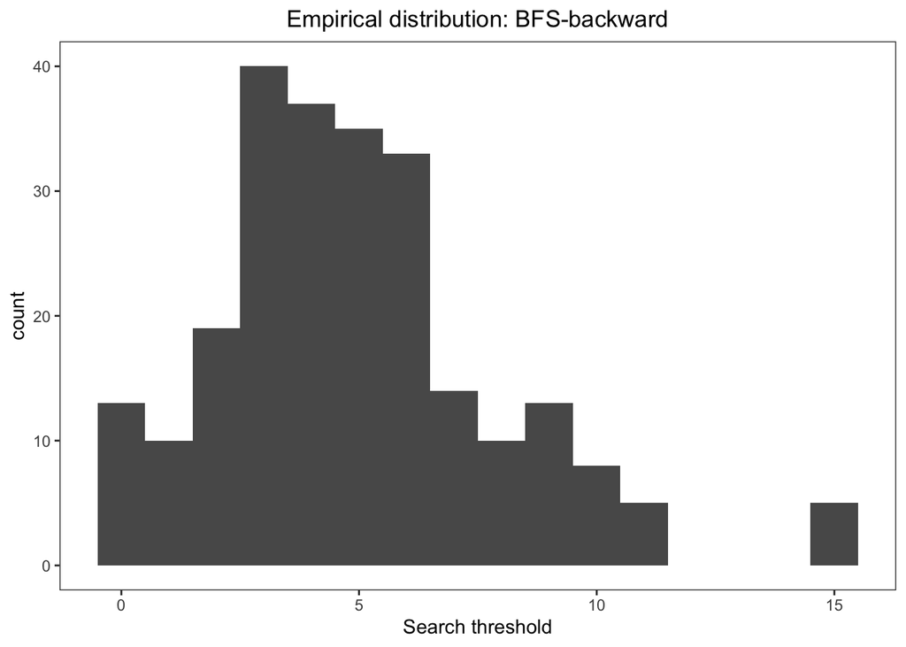

```r
plot_params_bfs_backward_empirical <- params %>%
  filter(model == "bfs_backward") %>%
  filter(measurement_id %in% c("D1", "D2")) %>%
  pivot_wider(names_from = param_name, values_from = param_value) %>%
  ggplot(aes(x=search_threshold)) +
  theme_custom() +
  geom_histogram(binwidth = 1) +
  xlab("Search threshold") +
  ggtitle("Empirical distribution: BFS-backward")

plot_params_bfs_backward_empirical
```

To simulate behavior, let’s sample from this distribution 500 times (with replacement, as the number of agents we’re simulating exceeds the number of real subjects/datapoints we have). To introduce a little bit of stochasticity, we’ll also add some Gaussian noise with a mean of 0 and a SD of 0.5.

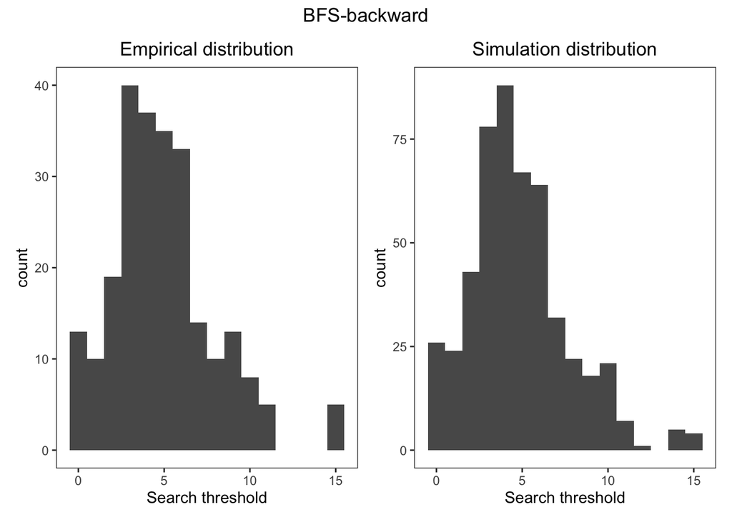

```r
set.seed(sum(utf8ToInt("We only said goodbye in words")))

sim_params_bfs_backward <- params %>%
  filter(model == "bfs_backward") %>%
  filter(measurement_id %in% c("D1", "D2")) %>%
  pivot_wider(names_from = param_name, values_from = param_value) %>%
  select(search_threshold) %>%
  deframe() %>%
  sample(size = 500, replace = TRUE) %>%
  enframe(name = "sub_id", value = "search_threshold") %>%
  mutate(
    search_threshold = search_threshold + rnorm(n = 500, mean = 0, sd = 0.5),
    search_threshold = case_when(
      search_threshold < 0 ~ runif(n = 1),
      search_threshold > 15 ~ runif(n = 1, min = 14, max = 15),
      TRUE ~ search_threshold
    )
  )

sim_behav_bfs_backward <- expand_grid(
  sub_id = 1:500,
  bfs_backward_sims
) %>%
  # Add subject-specific parameters
  left_join(sim_params_bfs_backward, by = join_by(sub_id)) %>%
  # What's the probability of *completing* BFS-online all the way through?
  rowwise() %>%
  mutate(
    p_complete_bfs = softmax(
      option_values = c(search_threshold, bfs_visits),
      option_chosen = 1,
      temperature = 1
    )
  ) %>%
  ungroup() %>%
  # Weigh BFS predictions accordingly
  mutate(
    p_give_up = 1 - p_complete_bfs,
    p_choose_opt1 = (
      (p_complete_bfs * p_bfs_chooses_opt1) + (p_give_up * 1/2)
    )
  ) %>%
  # Make binary choice in proportion to the probability of choosing opt1
  rowwise() %>%
  mutate(
    simulated_choice = sample(
      c(opt1_id, opt2_id), size = 1, prob = c(p_choose_opt1, 1-p_choose_opt1)
    )
  ) %>%
  ungroup()

plot_params_bfs_backward_simulated <- sim_params_bfs_backward %>%
  ggplot(aes(x=search_threshold)) +
  theme_custom() +
  geom_histogram(binwidth = 1) +
  xlab("Search threshold") +
  ggtitle("Simulation distribution")

plot_params_bfs_backward <- wrap_plots(
  plot_params_bfs_backward_empirical +
    ggtitle("Empirical distribution"),
  plot_params_bfs_backward_simulated
) &
  plot_annotation(
    title = "BFS-backward",
    theme = theme(plot.title = element_text(hjust = 0.5))
  )

plot_params_bfs_backward
```

```r
if (knitting) {
  ggsave(
    filename = here("outputs", workflow_name, "bfs_backward_param_dist.pdf"),
    plot = plot_params_bfs_backward,
    width = 5, height = 2.5,
    units = "in", dpi = 300
  )

  sim_behav_bfs_backward %>%
    write_csv(
      here(
        "data", "simulated_model_behaviors",
        "sim_nav_bfs_backward_confusion.csv"
      )
    )
}
```

# BFS-forward

We’ll re-use the BFS-backward simulation procedure for BFS-forward.

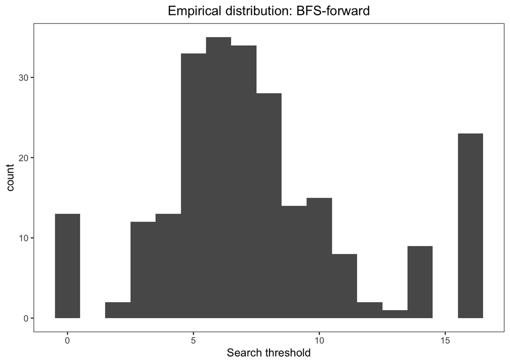

```r
plot_params_bfs_forward_empirical <- params %>%
  filter(model == "bfs_forward") %>%
  filter(measurement_id %in% c("D1", "D2")) %>%
  pivot_wider(names_from = param_name, values_from = param_value) %>%
  ggplot(aes(x=search_threshold)) +
  theme_custom() +
  geom_histogram(binwidth = 1) +
  xlab("Search threshold") +
  ggtitle("Empirical distribution: BFS-forward")

plot_params_bfs_forward_empirical
```

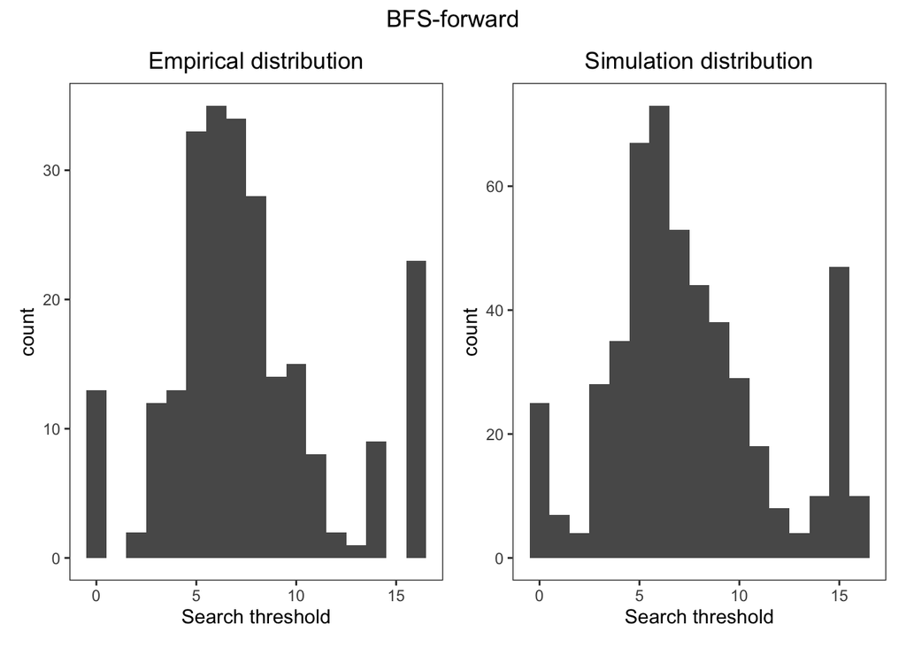

```r
set.seed(sum(utf8ToInt("Defiant to the end, we hear the call")))

sim_params_bfs_forward <- params %>%
  filter(model == "bfs_forward") %>%
  filter(measurement_id %in% c("D1", "D2")) %>%
  pivot_wider(names_from = param_name, values_from = param_value) %>%
  select(search_threshold) %>%
  deframe() %>%
  sample(size = 500, replace = TRUE) %>%
  enframe(name = "sub_id", value = "search_threshold") %>%
  mutate(
    search_threshold = search_threshold + rnorm(n = 500, mean = 0, sd = 0.5),
    search_threshold = case_when(
      search_threshold < 0 ~ runif(n = 1),
      search_threshold > 16 ~ runif(n = 1, min = 14, max = 16),
      TRUE ~ search_threshold
    )
  )

sim_behav_bfs_forward <- expand_grid(
  sub_id = 1:500,
  bfs_forward_sims
) %>%
  # Add subject-specific parameters
  left_join(sim_params_bfs_forward, by = join_by(sub_id)) %>%
  # What's the probability of *completing* BFS-online all the way through?
  rowwise() %>%
  mutate(
    p_complete_bfs = softmax(
      option_values = c(search_threshold, bfs_visits),
      option_chosen = 1,
      temperature = 1
    )
  ) %>%
  ungroup() %>%
  # Weigh BFS predictions accordingly
  mutate(
    p_give_up = 1 - p_complete_bfs,
    p_choose_opt1 = (
      (p_complete_bfs * p_bfs_chooses_opt1) + (p_give_up * 1/2)
    )
  ) %>%
  # Make binary choice in proportion to the probability of choosing opt1
  rowwise() %>%
  mutate(
    simulated_choice = sample(
      c(opt1_id, opt2_id), size = 1, prob = c(p_choose_opt1, 1-p_choose_opt1)
    )
  ) %>%
  ungroup()

plot_params_bfs_forward_simulated <- sim_params_bfs_forward %>%
  ggplot(aes(x=search_threshold)) +
  theme_custom() +
  geom_histogram(binwidth = 1) +
  xlab("Search threshold") +
  ggtitle("Simulation distribution")

plot_params_bfs_forward <- wrap_plots(
  plot_params_bfs_forward_empirical +
    ggtitle("Empirical distribution"),
  plot_params_bfs_forward_simulated
) &
  plot_annotation(
    title = "BFS-forward",
    theme = theme(plot.title = element_text(hjust = 0.5))
  )

plot_params_bfs_forward
```

```r
if (knitting) {
  ggsave(
    filename = here("outputs", workflow_name, "bfs_forward_param_dist.pdf"),
    plot = plot_params_bfs_forward,
    width = 5, height = 2.5,
    units = "in", dpi = 300
  )

  sim_behav_bfs_forward %>%
    write_csv(
      here(
        "data", "simulated_model_behaviors",
        "sim_nav_bfs_forward_confusion.csv"
      )
    )
}
```

# Ideal observer

As we can see, the distribution of fits is a bit exponential-looking for the ideal observer softmax temperature.

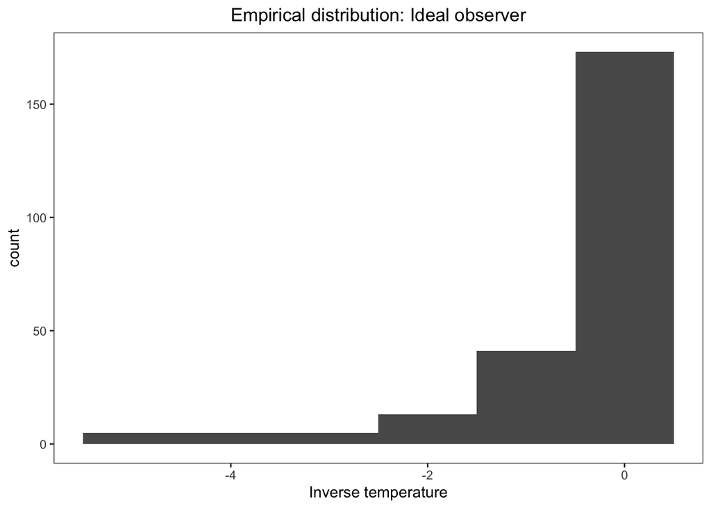

```r
plot_params_ideal_obs_empirical <- params %>%
  filter(model == "ideal_obs") %>%
  filter(measurement_id %in% c("D1", "D2")) %>%
  pivot_wider(names_from = param_name, values_from = param_value) %>%
  ggplot(aes(x=softmax_temperature)) +
  theme_custom() +
  geom_histogram(binwidth = 1) +
  xlab("Inverse temperature") +
  ggtitle("Empirical distribution: Ideal observer")

plot_params_ideal_obs_empirical
```

Accordingly, we’ll add Gaussian noise with mean = 0 and SD = 0.1.

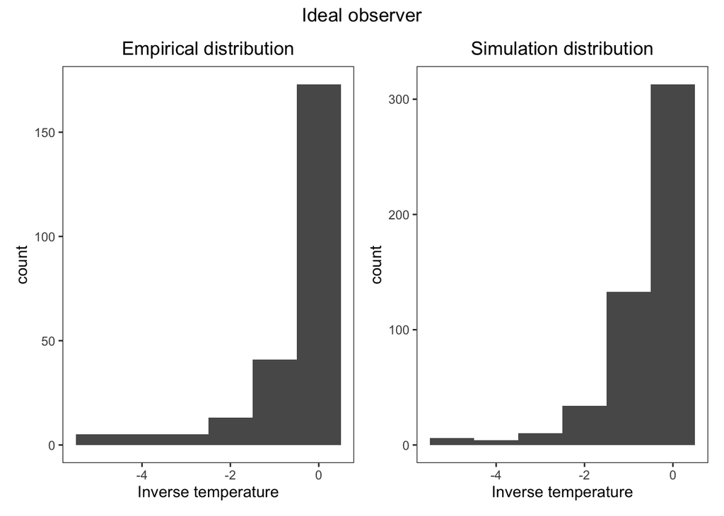

```r
set.seed(sum(utf8ToInt("Everyone outside swallow the light and creed")))

sim_params_ideal_obs <- params %>%
  filter(model == "ideal_obs") %>%
  filter(measurement_id %in% c("D1", "D2")) %>%
  pivot_wider(names_from = param_name, values_from = param_value) %>%
  select(softmax_temperature) %>%
  deframe() %>%
  sample(size = 500, replace = TRUE) %>%
  enframe(name = "sub_id", value = "softmax_temperature") %>%
  mutate(
    softmax_temperature = softmax_temperature +
      rnorm(n = 500, mean = 0, sd = 0.1),
    softmax_temperature = case_when(
      softmax_temperature > 0 ~ runif(n = 1, min = -1, max = 0),
      softmax_temperature < -5 ~ runif(n = 1, min = -5, max = -4),
      TRUE ~ softmax_temperature
    )
  )

sim_behav_ideal_obs <- expand_grid(
  sub_id = 1:500,
  nav_trials
) %>%
  # Add subject-specific parameters
  left_join(sim_params_ideal_obs, by = join_by(sub_id)) %>%
  rowwise() %>%
  mutate(
    p_choose_opt1 = softmax(
      option_values = c(opt1_distance, opt2_distance),
      option_chosen = 1,
      temperature = softmax_temperature,
      use_inverse_temperature = TRUE
    ),
    simulated_choice = sample(
      c(opt1_id, opt2_id), size = 1, prob = c(p_choose_opt1, 1-p_choose_opt1)
    )
  ) %>%
  ungroup()

plot_params_ideal_obs_simulated <- sim_params_ideal_obs %>%
  ggplot(aes(x=softmax_temperature)) +
  theme_custom() +
  geom_histogram(binwidth = 1) +
  xlab("Inverse temperature") +
  ggtitle("Simulation distribution")

plot_params_ideal_obs <- wrap_plots(
  plot_params_ideal_obs_empirical +
    ggtitle("Empirical distribution"),
  plot_params_ideal_obs_simulated
) &
  plot_annotation(
    title = "Ideal observer",
    theme = theme(plot.title = element_text(hjust = 0.5))
  )

plot_params_ideal_obs
```

```r
if (knitting) {
  ggsave(
    filename = here("outputs", workflow_name, "ideal_obs_param_dist.pdf"),
    plot = plot_params_ideal_obs,
    width = 5, height = 2.5,
    units = "in", dpi = 300
  )

  sim_behav_ideal_obs %>%
    write_csv(
      here(
        "data", "simulated_model_behaviors",
        "sim_nav_ideal_obs_confusion.csv"
      )
    )
}
```

# Successor Representation

For some subjects/datapoints, it looks like the optimizer estimated fairly extreme values of the softmax temperature. In successive plots, we’ll zoom in to emphasize more typical/representative values.

It’s clear that there’s a (nonlinear) association between gamma and temperature, so in our simulations, we’ll want to sample paired parameters.

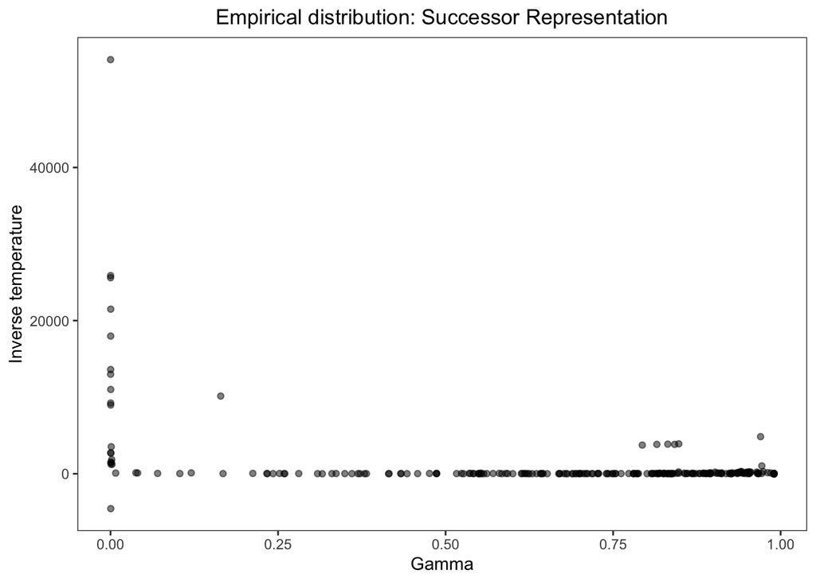

```r
params %>%
  filter(model == "sr_analytic") %>%
  filter(measurement_id %in% c("D1", "D2")) %>%
  pivot_wider(names_from = param_name, values_from = param_value) %>%
  ggplot(aes(x=sr_gamma, y=softmax_temperature)) +
  theme_custom() +
  geom_point(alpha = 0.5) +
  xlab("Gamma") +
  ylab("Inverse temperature") +
  ggtitle("Empirical distribution: Successor Representation")
```

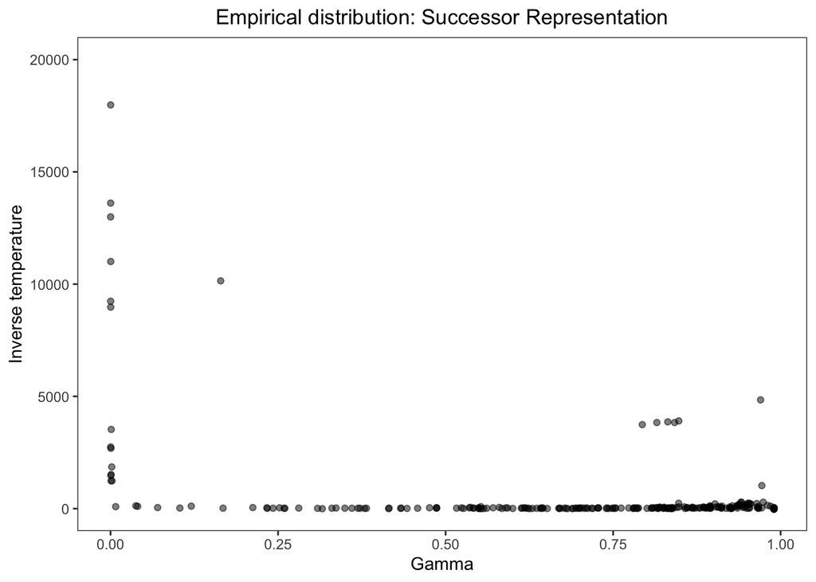

```r
params %>%
  filter(model == "sr_analytic") %>%
  filter(measurement_id %in% c("D1", "D2")) %>%
  pivot_wider(names_from = param_name, values_from = param_value) %>%
  ggplot(aes(x=sr_gamma, y=softmax_temperature)) +
  theme_custom() +
  geom_point(alpha = 0.5) +
  xlab("Gamma") +
  ylab("Inverse temperature") +
  ggtitle("Empirical distribution: Successor Representation") +
  coord_cartesian(ylim = c(0, 20000))
```

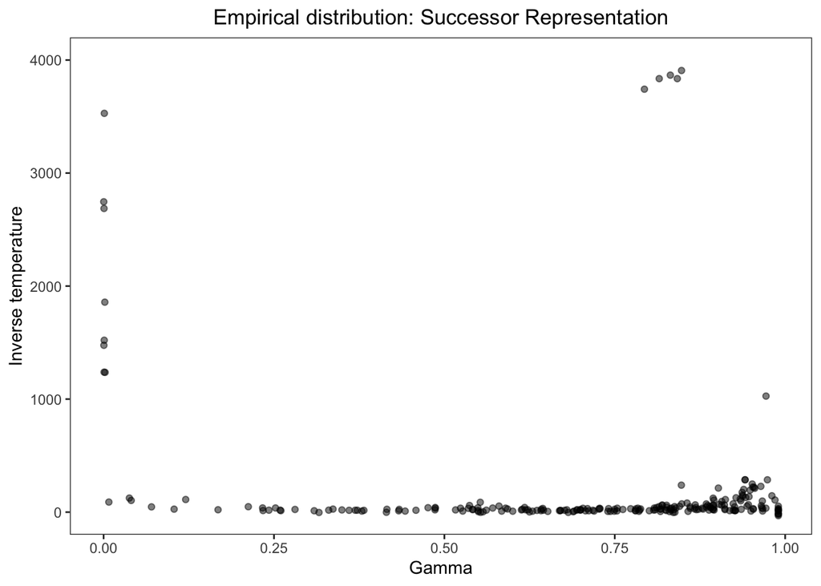

```r
params %>%
  filter(model == "sr_analytic") %>%
  filter(measurement_id %in% c("D1", "D2")) %>%
  pivot_wider(names_from = param_name, values_from = param_value) %>%
  ggplot(aes(x=sr_gamma, y=softmax_temperature)) +
  theme_custom() +
  geom_point(alpha = 0.5) +
  xlab("Gamma") +
  ylab("Inverse temperature") +
  ggtitle("Empirical distribution: Successor Representation") +
  coord_cartesian(ylim = c(0, 4000))
```

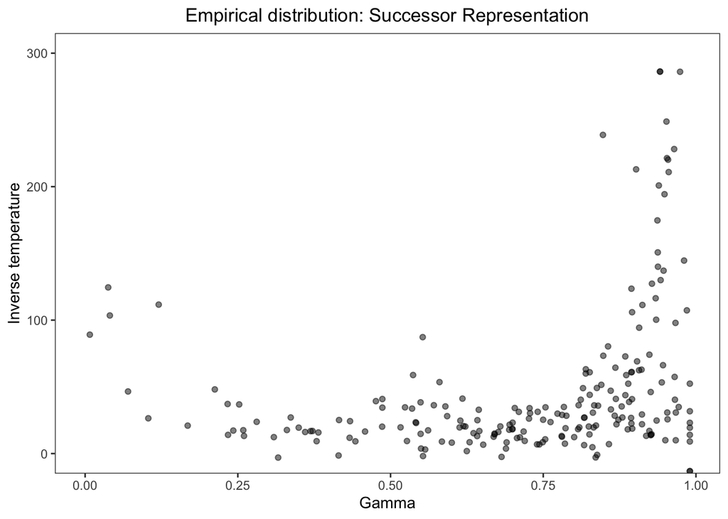

```r
plot_params_sr_empirical <- params %>%
  filter(model == "sr_analytic") %>%
  filter(measurement_id %in% c("D1", "D2")) %>%
  pivot_wider(names_from = param_name, values_from = param_value) %>%
  ggplot(aes(x=sr_gamma, y=softmax_temperature)) +
  theme_custom() +
  geom_point(alpha = 0.5) +
  xlab("Gamma") +
  ylab("Inverse temperature") +
  ggtitle("Empirical distribution: Successor Representation") +
  coord_cartesian(ylim = c(0, 300))

plot_params_sr_empirical
```

In the simulations, it doesn’t matter too much if there are extreme softmax temperatures; functionally, this will just end up looking like a hardmax choice rule in the behavior.

To the softmax temperatures, we’ll add Gaussian noise with SD = 5. To gamma, we’ll add Gaussian noise with SD = 0.04.

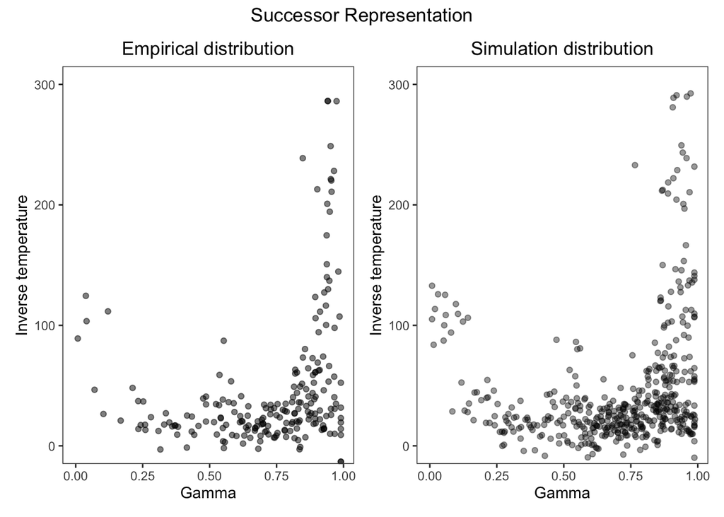

```r
set.seed(sum(utf8ToInt("Await the hunter to decipher the stone")))

sim_params_sr <- params %>%
  filter(model == "sr_analytic") %>%
  filter(measurement_id %in% c("D1", "D2")) %>%
  pivot_wider(names_from = param_name, values_from = param_value) %>%
  select(softmax_temperature, sr_gamma) %>%
  deframe() %>%
  sample(size = 500, replace = TRUE) %>%
  enframe(name = "softmax_temperature", value = "sr_gamma") %>%
  mutate(
    sub_id = row_number(),
    softmax_temperature = as.numeric(softmax_temperature),
    softmax_temperature = softmax_temperature +
      rnorm(n = 500, mean = 0, sd = 5),
    sr_gamma = sr_gamma + rnorm(n = 500, mean = 0, sd = 0.04),
    sr_gamma = case_when(
      sr_gamma < 0 ~ runif(n = 1, min = 0, max = 0.05),
      sr_gamma > 0.99 ~ runif(n = 1, min = 0.94, max = 0.99),
      TRUE ~ sr_gamma
    )
  )

sim_rep_sr <- sim_params_sr %>%
  rowwise() %>%
  mutate(
    predicted_sr = map(
      .x = sr_gamma,
      .f = ~build_successor_analytically(
        transmat, successor_horizon = .x, normalize = TRUE
      )
    )
  ) %>%
  ungroup() %>%
  select(sub_id, predicted_sr) %>%
  unnest(predicted_sr)

sim_behav_sr <- expand_grid(
  sub_id = 1:500,
  nav_trials
) %>%
  # Add subject-specific parameters
  left_join(sim_params_sr, by = join_by(sub_id)) %>%
  # Add subject-specific predicted SR
  left_join(
    sim_rep_sr %>%
      select(sub_id, endpoint_id = to, opt1_id = from, opt1_sr = sr_value),
    by = join_by(sub_id, endpoint_id, opt1_id)
  ) %>%
  left_join(
    sim_rep_sr %>%
      select(sub_id, endpoint_id = to, opt2_id = from, opt2_sr = sr_value),
    by = join_by(sub_id, endpoint_id, opt2_id)
  ) %>%
  # Calculate probability of choosing opt1 given parameters + predicted SR
  # Then make binary choice in proportion to that probability
  rowwise() %>%
  mutate(
    p_choose_opt1 = softmax(
      option_values = c(opt1_sr, opt2_sr),
      option_chosen = 1,
      temperature = softmax_temperature,
      use_inverse_temperature = TRUE
    ),
    # Extreme softmax temps may cause NaNs
    p_choose_opt1 = case_when(
      is.nan(p_choose_opt1) & (opt1_sr > opt2_sr) ~ 1,
      TRUE ~ p_choose_opt1
    ),
    simulated_choice = sample(
      c(opt1_id, opt2_id), size = 1, prob = c(p_choose_opt1, 1-p_choose_opt1)
    )
  ) %>%
  ungroup()

plot_params_sr_simulated <- sim_params_sr %>%
  ggplot(aes(x=sr_gamma, y=softmax_temperature)) +
  theme_custom() +
  geom_point(alpha = 0.4) +
  xlab("Gamma") +
  ylab("Inverse temperature") +
  ggtitle("Simulation distribution") +
  coord_cartesian(ylim = c(0, 300))

plot_params_sr <- wrap_plots(
  plot_params_sr_empirical +
    ggtitle("Empirical distribution"),
  plot_params_sr_simulated
) &
  plot_annotation(
    title = "Successor Representation",
    theme = theme(plot.title = element_text(hjust = 0.5))
  )

plot_params_sr
```

```r
if (knitting) {
  ggsave(
    filename = here("outputs", workflow_name, "sr_param_dist.pdf"),
    plot = plot_params_sr,
    width = 5, height = 2.5,
    units = "in", dpi = 300
  )

  sim_behav_sr %>%
    write_csv(
      here(
        "data", "simulated_model_behaviors",
        "sim_nav_sr_confusion.csv"
      )
    )
}
```